# R Básico

Clase 3

Bladimir Morales Torrez

# 1 Transformación de los Datos

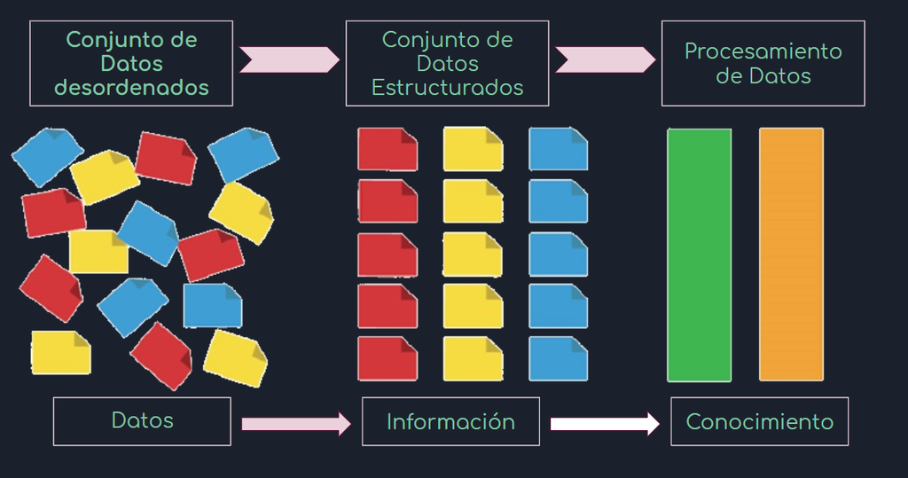

Transformación de los Datos

## 1.1 Tipos de Bases de Datos

Existen diferentes tipos de bases de datos

- Estructuradas
- No Estructuradas

También existen diferentes tipos de formatos de bases de datos

- csv
- xlsx
- xml
- sql
- HDF
- NetCDF
- json
- dta
- sav
- jpeg
- png
- svg
- GML
- GPX
- GIS
- GeoJson

## 1.2 Investigaciones

Para cualquier proyecto de investigación los pasos a seguir son:

- Objetivos
- Marco conceptual
- Recolección de información (encuestas, datos de internet, censos, etc.)
- **Estructuración de los datos**
- Análisis de datos/información
- Conclusiones/Recomendaciones
- Toma de decisiones

## 1.3 Exportar e Importar Datos

Se puede importar datos de diferentes fuentes. Veremos las mas utilizadas:

```r
#Directorio de trabajo
getwd()
```

```
[1] "C:/Users/ACER/Documents/Proyectos/curso_rbasico/curso_rbasico"
```

```r
#Cargar nuevo directorio de trabajo
#setwd("C:/Users/ACER/Documents/Proyectos/curso_rbasico/curso_rbasico/bd")
```

## 1.4 csv Exportar/Importar

Los archivos csv (comma-separated values) valores separados por comas.

```r
#Importar
bd_covid<-read.csv("covid19mun_se.csv",encoding = "UTF-8")
```

```r
#Exportar
write.csv(bd_covid,"covid19mun.csv",sep = ",", fileEncoding = "UTF-8")
write.csv(bd_covid,"covid19mun.csv",sep = ",", fileEncoding = "UTF-8",row.names = FALSE)
```

```r
bd_covid<-read.table("covid19mun_se.csv",encoding = "UTF-8",sep = ",",header=TRUE)
```

## 1.5 Excel Exportar/Importar

```r
#install.packages("readxl")
library(readxl)
```

```r
#install.packages("writexl")
library(writexl)
```

```r
#Exportar
write_xlsx(bd_covid,"covid19mun.xlsx")
```

```r
#Importar
bd_covid1<-read_xlsx("covid19mun.xlsx")
```

# 2 Introducción a la libreria “dplyr”

El paquete `dplyr` de R, que fué desarrollado por Hadley Wickham y Romain Francois, como una optimización del paquete `plyr`.

Este paquete ofrece diferentes bondades en el manejo y administración de data frames en R, ya que simplifica muchas cosas desde la facilidad del código, una mejor funcionalidad y es mucho más rápido en su procesamiento, porque muchas de las operaciones están codificadas en C ++.

Las funciones principales del paquete son:

- `filter`: extrae/filtra un subconjunto de filas de un data frame basado en una condición lógica.
- `select`: retorna un subconjunto de columnas de un data frame.
- `group_by`: agrupa los datos en el data frame de acuerdo a las variables.
- `summarise`/`summarize`: genera estadísticas resumidas de diferentes variables.
- `arrange`: ordena las filas de un data frame en función de los valores de una o más columnas.
- `rename`: renombra variables en un data frame.
- `mutate`: añade nuevas variables/columnas o las transforma.
- `pipe %>%`: es un operador utilizado para conectar funciones.

```r
#install.packages("dplyr")
library(dplyr)
```

# 3 Funcionalidades de la libreria “dplyr”

```r
str(bd_covid)
```

```
'data.frame':   6144 obs. of  9 variables:
 $ CODDEPTO      : int  1 1 1 2 2 2 2 2 2 2 ...
 $ DEPARTAMENTO  : chr  "CHUQUISACA" "CHUQUISACA" "CHUQUISACA" "LA PAZ" ...
 $ Codigo        : int  10101 10501 10902 20101 20105 20201 20801 20904 20905 21003 ...
 $ MUNICIPIO     : chr  "SUCRE" "MONTEAGUDO" "CULPINA" "LA PAZ" ...
 $ SE            : int  20 20 20 20 20 20 20 20 20 20 ...
 $ CONFIRMADOS   : int  14 1 1 152 126 1 5 1 11 1 ...
 $ ACTIVOS       : int  11 1 1 59 70 0 3 1 2 0 ...
 $ FALLECIDOS    : int  2 0 0 8 8 0 0 0 0 0 ...
 $ RECUPERADOS...: int  1 0 0 85 48 1 2 0 9 1 ...
```

| CODDEPTO | DEPARTAMENTO | Codigo | MUNICIPIO | SE | CONFIRMADOS | ACTIVOS | FALLECIDOS | RECUPERADOS... |
| --- | --- | --- | --- | --- | --- | --- | --- | --- |
| 1 | CHUQUISACA | 10101 | SUCRE | 20 | 14 | 11 | 2 | 1 |
| 1 | CHUQUISACA | 10501 | MONTEAGUDO | 20 | 1 | 1 | 0 | 0 |
| 1 | CHUQUISACA | 10902 | CULPINA | 20 | 1 | 1 | 0 | 0 |
| 2 | LA PAZ | 20101 | LA PAZ | 20 | 152 | 59 | 8 | 85 |
| 2 | LA PAZ | 20105 | EL ALTO | 20 | 126 | 70 | 8 | 48 |
| 2 | LA PAZ | 20201 | ACHACACHI | 20 | 1 | 0 | 0 | 1 |
| 2 | LA PAZ | 20801 | VIACHA | 20 | 5 | 3 | 0 | 2 |
| 2 | LA PAZ | 20904 | MALLA | 20 | 1 | 1 | 0 | 0 |
| 2 | LA PAZ | 20905 | CAIROMA | 20 | 11 | 2 | 0 | 9 |
| 2 | LA PAZ | 21003 | CAJUATA | 20 | 1 | 0 | 0 | 1 |

[output cut: 990 more lines]

## 3.1 rename

`rename`: renombra variables en un data frame.

| CODDEPTO | depto | Codigo | MUNICIPIO | SE | CONFIRMADOS | ACTIVOS | FALLECIDOS | RECUPERADOS... |
| --- | --- | --- | --- | --- | --- | --- | --- | --- |
| 1 | CHUQUISACA | 10101 | SUCRE | 20 | 14 | 11 | 2 | 1 |
| 1 | CHUQUISACA | 10501 | MONTEAGUDO | 20 | 1 | 1 | 0 | 0 |
| 1 | CHUQUISACA | 10902 | CULPINA | 20 | 1 | 1 | 0 | 0 |
| 2 | LA PAZ | 20101 | LA PAZ | 20 | 152 | 59 | 8 | 85 |
| 2 | LA PAZ | 20105 | EL ALTO | 20 | 126 | 70 | 8 | 48 |
| 2 | LA PAZ | 20201 | ACHACACHI | 20 | 1 | 0 | 0 | 1 |
| 2 | LA PAZ | 20801 | VIACHA | 20 | 5 | 3 | 0 | 2 |
| 2 | LA PAZ | 20904 | MALLA | 20 | 1 | 1 | 0 | 0 |
| 2 | LA PAZ | 20905 | CAIROMA | 20 | 11 | 2 | 0 | 9 |
| 2 | LA PAZ | 21003 | CAJUATA | 20 | 1 | 0 | 0 | 1 |

[output cut: 990 more lines]

## 3.2 filter

`filter`: extrae/filtra un subconjunto de filas de un data frame basado en una condición lógica.

| CODDEPTO | DEPARTAMENTO | Codigo | MUNICIPIO | SE | CONFIRMADOS | ACTIVOS | FALLECIDOS | RECUPERADOS... |
| --- | --- | --- | --- | --- | --- | --- | --- | --- |
| 2 | LA PAZ | 20101 | LA PAZ | 20 | 152 | 59 | 8 | 85 |
| 2 | LA PAZ | 20105 | EL ALTO | 20 | 126 | 70 | 8 | 48 |
| 2 | LA PAZ | 20201 | ACHACACHI | 20 | 1 | 0 | 0 | 1 |
| 2 | LA PAZ | 20801 | VIACHA | 20 | 5 | 3 | 0 | 2 |
| 2 | LA PAZ | 20904 | MALLA | 20 | 1 | 1 | 0 | 0 |
| 2 | LA PAZ | 20905 | CAIROMA | 20 | 11 | 2 | 0 | 9 |
| 2 | LA PAZ | 21003 | CAJUATA | 20 | 1 | 0 | 0 | 1 |
| 2 | LA PAZ | 21101 | CHULUMANI (V. DE LA LIBERTAD) | 20 | 1 | 1 | 0 | 0 |
| 2 | LA PAZ | 21202 | LAJA | 20 | 1 | 1 | 0 | 0 |
| 2 | LA PAZ | 21301 | SICA SICA (VILLA AROMA) | 20 | 2 | 0 | 1 | 1 |

[output cut: 990 more lines]

## 3.3 select

`select`: retorna un subconjunto de columnas de un data frame.

| DEPARTAMENTO | MUNICIPIO | CONFIRMADOS |
| --- | --- | --- |
| CHUQUISACA | SUCRE | 14 |
| CHUQUISACA | MONTEAGUDO | 1 |
| CHUQUISACA | CULPINA | 1 |
| LA PAZ | LA PAZ | 152 |
| LA PAZ | EL ALTO | 126 |
| LA PAZ | ACHACACHI | 1 |
| LA PAZ | VIACHA | 5 |
| LA PAZ | MALLA | 1 |
| LA PAZ | CAIROMA | 11 |
| LA PAZ | CAJUATA | 1 |

[output cut: 990 more lines]

| DEPARTAMENTO | MUNICIPIO | SE | CONFIRMADOS | ACTIVOS |
| --- | --- | --- | --- | --- |
| CHUQUISACA | SUCRE | 20 | 14 | 11 |
| CHUQUISACA | MONTEAGUDO | 20 | 1 | 1 |
| CHUQUISACA | CULPINA | 20 | 1 | 1 |
| LA PAZ | LA PAZ | 20 | 152 | 59 |
| LA PAZ | EL ALTO | 20 | 126 | 70 |
| LA PAZ | ACHACACHI | 20 | 1 | 0 |
| LA PAZ | VIACHA | 20 | 5 | 3 |
| LA PAZ | MALLA | 20 | 1 | 1 |
| LA PAZ | CAIROMA | 20 | 11 | 2 |
| LA PAZ | CAJUATA | 20 | 1 | 0 |

[output cut: 990 more lines]

## 3.4 group_by

`group_by`: agrupa los datos en el data frame de acuerdo a las variables.

| CODDEPTO | DEPARTAMENTO | Codigo | MUNICIPIO | SE | CONFIRMADOS | ACTIVOS | FALLECIDOS | RECUPERADOS... |
| --- | --- | --- | --- | --- | --- | --- | --- | --- |
| 1 | CHUQUISACA | 10101 | SUCRE | 20 | 14 | 11 | 2 | 1 |
| 1 | CHUQUISACA | 10501 | MONTEAGUDO | 20 | 1 | 1 | 0 | 0 |
| 1 | CHUQUISACA | 10902 | CULPINA | 20 | 1 | 1 | 0 | 0 |
| 2 | LA PAZ | 20101 | LA PAZ | 20 | 152 | 59 | 8 | 85 |
| 2 | LA PAZ | 20105 | EL ALTO | 20 | 126 | 70 | 8 | 48 |
| 2 | LA PAZ | 20201 | ACHACACHI | 20 | 1 | 0 | 0 | 1 |
| 2 | LA PAZ | 20801 | VIACHA | 20 | 5 | 3 | 0 | 2 |
| 2 | LA PAZ | 20904 | MALLA | 20 | 1 | 1 | 0 | 0 |
| 2 | LA PAZ | 20905 | CAIROMA | 20 | 11 | 2 | 0 | 9 |
| 2 | LA PAZ | 21003 | CAJUATA | 20 | 1 | 0 | 0 | 1 |

[output cut: 990 more lines]

## 3.5 summarise

`summarise`/`summarize`: genera estadísticas resumidas de diferentes variables.

|  | DEPARTAMENTO | n_confirmados | sum_confirmados | media_confirmados | sd_confirmados |
| --- | --- | --- | --- | --- | --- |
| 1 | BENI | 361 | 133747 | 370.4903 | 882.1778 |
| 2 | CHUQUISACA | 553 | 96542 | 174.5787 | 863.2965 |
| 3 | COCHABAMBA | 968 | 221054 | 228.3616 | 974.6967 |
| 4 | LA PAZ | 1347 | 502330 | 372.9250 | 2427.7449 |
| 5 | ORURO | 500 | 88879 | 177.7580 | 757.0716 |
| 6 | PANDO | 258 | 38429 | 148.9496 | 396.9433 |
| 7 | POTOSI | 660 | 108083 | 163.7621 | 568.5584 |
| 8 | SANTA CRUZ | 1257 | 776950 | 618.0986 | 3168.8705 |
| 9 | TARIJA | 240 | 179944 | 749.7667 | 1649.6564 |

## 3.6 mutate

`mutate`: añade nuevas variables/columnas o las transforma.

| CODDEPTO | DEPARTAMENTO | Codigo | MUNICIPIO | SE | CONFIRMADOS | ACTIVOS | FALLECIDOS | RECUPERADOS... | ajuste_confirmados | verificacion |
| --- | --- | --- | --- | --- | --- | --- | --- | --- | --- | --- |
| 1 | CHUQUISACA | 10101 | SUCRE | 20 | 14 | 11 | 2 | 1 | 14 | Si |
| 1 | CHUQUISACA | 10501 | MONTEAGUDO | 20 | 1 | 1 | 0 | 0 | 1 | Si |
| 1 | CHUQUISACA | 10902 | CULPINA | 20 | 1 | 1 | 0 | 0 | 1 | Si |
| 2 | LA PAZ | 20101 | LA PAZ | 20 | 152 | 59 | 8 | 85 | 152 | Si |
| 2 | LA PAZ | 20105 | EL ALTO | 20 | 126 | 70 | 8 | 48 | 126 | Si |
| 2 | LA PAZ | 20201 | ACHACACHI | 20 | 1 | 0 | 0 | 1 | 1 | Si |
| 2 | LA PAZ | 20801 | VIACHA | 20 | 5 | 3 | 0 | 2 | 5 | Si |
| 2 | LA PAZ | 20904 | MALLA | 20 | 1 | 1 | 0 | 0 | 1 | Si |
| 2 | LA PAZ | 20905 | CAIROMA | 20 | 11 | 2 | 0 | 9 | 11 | Si |
| 2 | LA PAZ | 21003 | CAJUATA | 20 | 1 | 0 | 0 | 1 | 1 | Si |

[output cut: 990 more lines]

## 3.7 arrange

`arrange`: ordena las filas de un data frame en función de los valores de una o más columnas.

| CODDEPTO | DEPARTAMENTO | Codigo | MUNICIPIO | SE | CONFIRMADOS | ACTIVOS | FALLECIDOS | RECUPERADOS... |
| --- | --- | --- | --- | --- | --- | --- | --- | --- |
| 5 | POTOSI | 51302 | ACACIO | 29 | 2 | 2 | 0 | 0 |
| 5 | POTOSI | 51302 | ACACIO | 30 | 4 | 4 | 0 | 0 |
| 5 | POTOSI | 51302 | ACACIO | 31 | 4 | 4 | 0 | 0 |
| 5 | POTOSI | 51302 | ACACIO | 32 | 4 | 4 | 0 | 0 |
| 5 | POTOSI | 51302 | ACACIO | 33 | 4 | 4 | 0 | 0 |
| 5 | POTOSI | 51302 | ACACIO | 34 | 4 | 4 | 0 | 0 |
| 5 | POTOSI | 51302 | ACACIO | 35 | 4 | 4 | 0 | 0 |
| 5 | POTOSI | 51302 | ACACIO | 36 | 9 | 9 | 0 | 0 |
| 5 | POTOSI | 51302 | ACACIO | 37 | 9 | 9 | 0 | 0 |
| 5 | POTOSI | 51302 | ACACIO | 38 | 11 | 11 | 0 | 0 |

[output cut: 990 more lines]

| CODDEPTO | DEPARTAMENTO | Codigo | MUNICIPIO | SE | CONFIRMADOS | ACTIVOS | FALLECIDOS | RECUPERADOS... |
| --- | --- | --- | --- | --- | --- | --- | --- | --- |
| 1 | CHUQUISACA | 10101 | SUCRE | 48 | 6572 | 193 | 475 | 5904 |
| 1 | CHUQUISACA | 10102 | YOTALA | 48 | 107 | 0 | 3 | 104 |
| 1 | CHUQUISACA | 10103 | POROMA | 48 | 15 | 0 | 0 | 15 |
| 1 | CHUQUISACA | 10201 | AZURDUY | 48 | 31 | 2 | 0 | 29 |
| 1 | CHUQUISACA | 10202 | TARVITA | 48 | 34 | 27 | 0 | 7 |
| 1 | CHUQUISACA | 10301 | ZUDAÑEZ | 48 | 44 | 6 | 0 | 38 |
| 1 | CHUQUISACA | 10302 | PRESTO | 48 | 76 | 4 | 1 | 71 |
| 1 | CHUQUISACA | 10303 | MOJOCOYA | 48 | 35 | 8 | 2 | 25 |
| 1 | CHUQUISACA | 10304 | ICLA | 48 | 17 | 2 | 0 | 15 |
| 1 | CHUQUISACA | 10401 | PADILLA | 48 | 27 | 8 | 0 | 19 |

[output cut: 990 more lines]

## 3.8 Operador “pipe”

`pipe %>%`: es un operador utilizado para conectar funciones.